# Bayesian Regression

Mine Dogucu

**Getting started**

- We have provided an `.Rmd` file for this activity: `R/03-regression-activity.Rmd`. We recommend that you avoid knitting often and rely more on the `Run Current Chunk` feature, as it will take some time to simulate the Bayesian models.
- If you prefer to use an `R` file, first make sure that you’re working within your directory with the repo files, and then run the following from the Console:  
  `knitr::purl("R/03-regression-activity.Rmd", "R/03-regression-activity.R")`

  This will create an R file with the activity R code. For the corresponding discussion and prompts, see the `R/03-regression-activity.html` file in the repo.

```r
# Load packages
library(bayesrules)
library(tidyverse)
library(rstanarm)
library(bayesplot)
library(janitor)
```

# Background

*Capital Bikeshare* is a bike sharing service in the Washington, D.C. area. Using the `bikes` data, our analysis will focus on the relationship between number of bikeshare rides ($Y$: `rides`), and temperature ($X$: temp_feel). We will model:

$$\mu_i = \beta_0 + \beta_1X_i$$

$\beta_0$ is the typical ridership on days in which the temperature was 0 degrees ( $X_i$=0). It is not interpretable in this case.

$\beta_1$ is the typical change in ridership for every one unit increase in temperature.

**likelihood:** $Y_i | \beta_0, \beta_1, \sigma \;\;\;\stackrel{ind}{\sim} N\left(\mu_i, \sigma^2\right)\text{ with } \mu_i = \beta_0 + \beta_1X_i$

**prior models:**

$\beta_0\sim N(m_0, s_0^2 )$  
$\beta_1\sim N(m_1, s_1^2 )$  
$\sigma \sim \text{Exp}(l)$

Since we have done some hands-on activities before this related to setting priors, in this activity we will follow along with some uninformative priors together and focus mostly on the posterior.

# Posterior Simulation

```r
bike_model <- stan_glm(rides ~ temp_feel, data = bikes,
                       family = gaussian,
                       prior_intercept = normal(5000, 1000),
                       prior = normal(100, 40),
                       prior_aux = exponential(0.0008),
                       chains = 4, iter = 5000*2, seed = 84735, refresh = FALSE)
```

**Exercise: stan_glm()**

Can you identify each argument of the `stan_glm()` function and what their purpose is?

## Interpreting the posterior

**bayesplot** package provides many plotting functions that can help us quickly examine the MCMC draws.

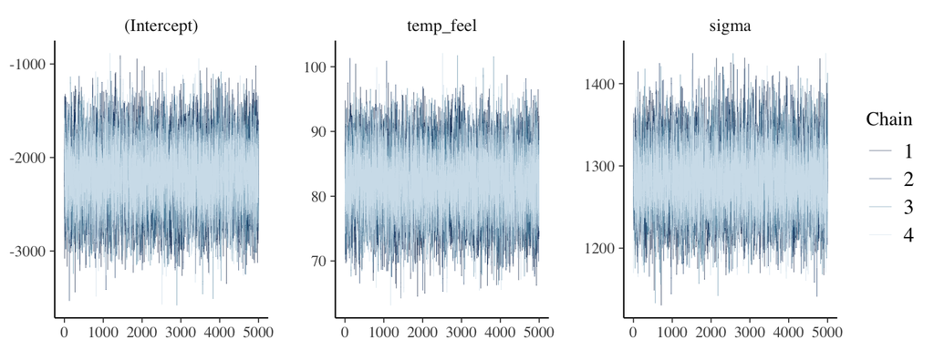

```r
mcmc_trace(bike_model, size = 0.1)
```

**Exercise: traceplots**

Do the traceplots provide evidence that chains are stable?

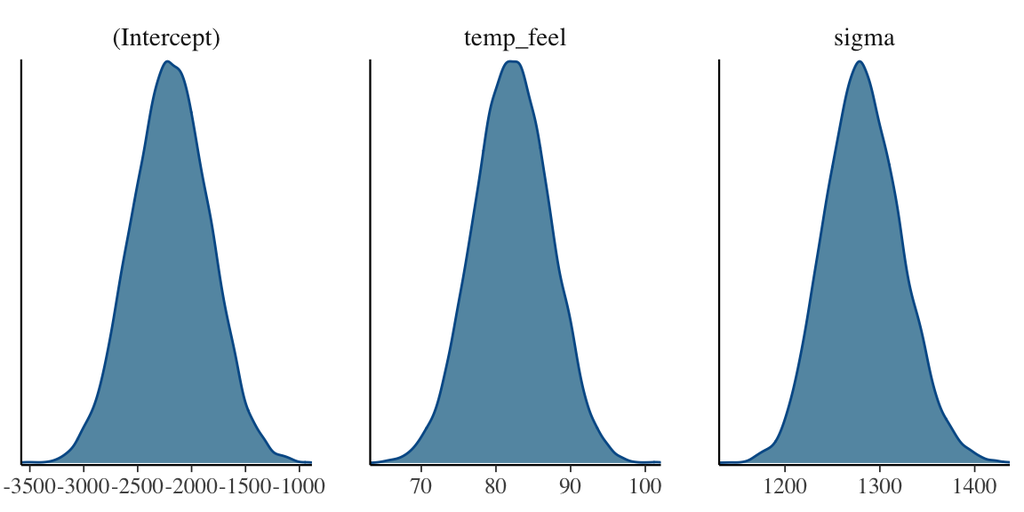

```r
mcmc_dens(bike_model)
```

**Exercise: density plots**

Looking at the density plots of the posterior simulation what can you conclude about the intercept and the slope? Do you think we have enough evidence to believe that the relationship between ridership and temperature is a positive one?

# Posterior prediction

Our goal in this part is to simulate 20,000 predictions of ridership on a 75 degree day. First, let’s get our model results into a data frame.

```r
# Store the 4 chains for each parameter in 1 data frame
bike_model_df <- as.data.frame(bike_model)

# Check it out
nrow(bike_model_df)
```

```
## [1] 20000
```

```r
head(bike_model_df, 3)
```

```
##   (Intercept) temp_feel    sigma
## 1   -2656.894  88.16061 1323.364
## 2   -2188.090  83.01252 1322.962
## 3   -1983.816  81.53971 1363.346
```

We have 20000 rows one for each iteration and 3 columns one for each parameter. Let’s focus on the first row of this data

```r
first_set <- head(bike_model_df, 1)
first_set
```

```
##   (Intercept) temp_feel    sigma
## 1   -2656.894  88.16061 1323.364
```

Under this particular scenario, $\left(\beta_0^{(1)}, \beta_1^{(1)}, \sigma^{(1)}\right) = (-2657, 88.16, 1323)$, the average ridership at a given temperature is defined by

$$\mu = \beta_0^{(1)} + \beta_1^{(1)} X = -2657 + 88.16X \; .$$

As such, we’d expect an **average** of $\mu = 3955$ riders on a 75 degree day:

```r
mu <- first_set$`(Intercept)` + first_set$temp_feel * 75
mu
```

```
## [1] 3955.152
```

To capture the **sampling variability** around this average, i.e. the fact that not all 75 degree days have the same ridership, we can simulate our first official prediction $Y_{\text{new}}^{(1)}$ by taking a random draw from the Normal model specified by this first parameter set:

$$Y_{\text{new}}^{(1)} | \beta_0, \beta_1, \sigma \; \sim \; N\left(3955, 1323^2\right) \; .$$

Taking a draw from this model using `rnorm()`, we happen to observe an above average 4838 rides on the 75 degree day:

```r
set.seed(84735)
y_new <- rnorm(1, mean = mu, sd = first_set$sigma)
y_new
```

```
## [1] 4838.144
```

Now let’s do this 19,999 more times. That is, let’s follow the same two-step process to simulate a prediction of ridership from each of the 20,000 sets of regression parameters $i$ in `bike_model_df`: (1) calculate the *average* ridership on 75 degree days, $\mu^{(i)} = \beta_0^{(i)} + \beta_1^{(i)}\cdot 75$; then (2) sample from the Normal model centered at this average with standard deviation $\sigma^{(i)}$:

```r
# Predict rides for each parameter set in the chain
set.seed(84735)
predict_75 <- bike_model_df %>%
  mutate(mu = `(Intercept)` + temp_feel*75,
         y_new = rnorm(20000, mean = mu, sd = sigma))
```

```r
head(predict_75, 3)
```

```
##   (Intercept) temp_feel    sigma       mu    y_new
## 1   -2656.894  88.16061 1323.364 3955.152 4838.144
## 2   -2188.090  83.01252 1322.962 4037.849 3874.013
## 3   -1983.816  81.53971 1363.346 4131.662 5196.255
```

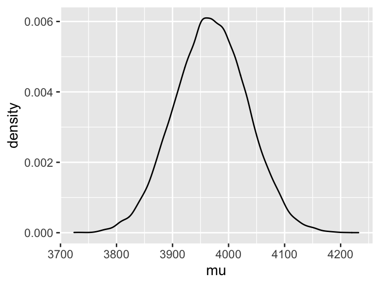

```r
# Plot the posterior model of the typical ridership on 75 degree days
ggplot(predict_75, aes(x = mu)) +
  geom_density()
```

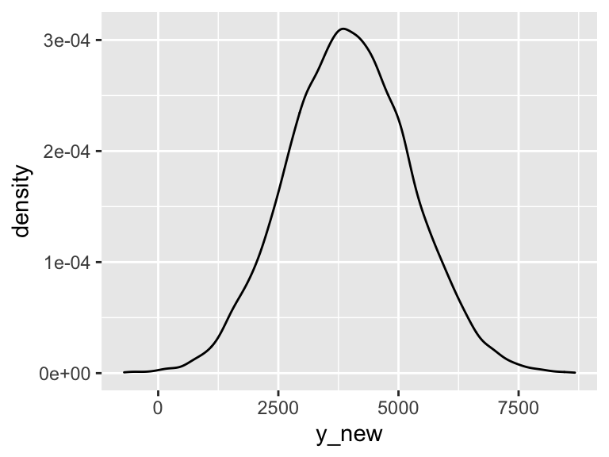

```r
# Plot the posterior predictive model of tomorrow's ridership
ggplot(predict_75, aes(x = y_new)) +
  geom_density()
```

**Exercise: evaluating predictions**

Now that we have predictions for ridership for a day, how would you assess if our prediction is a good one or not? Remember that, all models are wrong[^1]. It might make more sense to discuss how you would assess how *bad* the prediction is. We will not have R code for this in the workshop as we wrap things up but answering it conceptually in your groups would be good.

# Discussion

Please take a few minutes to plan what is ahead for you in your teaching and discuss in your breakout room.

- Will you be teaching a Bayesian course or incorporating Bayesian concepts in your courses?
- What activities (among those we covered or another activity that you know/thought of) would you take to your classroom?
- What computing infrastructure do you plan on using for your course?
[^1]: George Box